# White Shark Number of Breeders Re-Analysis 2022

Dani Davenport

# Overview

This document/repository contains and outlines the re-analysis of the data presented in Davenport et al 2021.

The authors were made aware of a bug or error in the output-files used in both NeEstimator and Colony to estimate the number of breeders per cohort. This error caused the data to become shuffled. Below, analysis is presented comparing the published data to files made directly from the original raw data. The input files for Nb estimation for NeEstimator and COLONY are re-made using raw data (based on the published loci) and the updated results are presented. The published work further sought to combine estimators of effective size to make reporting and decision making easier - combined estimates of Nb per-cohort. Here using the revised results we also make these re-estimates.

An additional sensitivity analysis is performed on the full dataset to illustrate how the inclusion of different SNPs and individuals can affect final point-estimates of effective size, and highlights the importance of considering confidence intervals (i.e using a 95%CI we expect that 95% of the time the true value of the parameter lies in its interval), as well as various estimators in conservation decisions.

# BACKROUND

In Davenport et al., 2021, the effective number of breeders (Nb) was estimated in 4 consecutive cohorts (2010-2013) based on the premise that when a genetic sample contains only individuals from a single age cohort (a group of individuals having the same age-class), then the estimate of effective population size (Ne) from a single-sample estimator in species with overlapping generations corresponds to the effective number of breeders (Nb). For long-lived, iteroparous species such as the white shark, estimates of Nb are generally considered more useful for monitoring as they apply to a single breeding season (rather than needing a sample representative of a generation - an assumption of Ne (see Waples (2022))), and it represents an accessible parameter for monitoring population trends at ecological timescales most relevant to conservation and management needs. Nb is particularly useful in cases where juvenile or YOY samples can be easily collected (i.e. through SMART shark program NSW). Estimating Nb and monitoring its change over time allows timely detection of population trends (decline, restoration, recovery, expansion), even if using as few as four or five consecutive reproductive cycles (Leberg (2005); Wang (2005); Luikart et al. (2021)).

# METHODS

## DATA

The original DArT data for this project can be found in the file Data/Raw  
The results of the reanalysis can be found in Results/ and Data/

The filtered list of loci from the published analysis can be found in Data/Raw/Report-DSha18-3402/File_Formats/Genepop_NeEstimator_Input/nswdpi_whiteshark_gp.gen. The loci names were extracted from this document to ensure the data from the publication are used in the reanalysis here. Readers are referred to the original publication for more detailed methods. In summary, a list of loci/SNPs which meet the articles filtering criteria are saved in the ‘.gen’ file. These are used here to re-make the input files for NeEstimator and Colony from the original raw-data, from which Nb per cohort is re-estimated.The full raw data is also used to re-estimate Nb using a sensitivity analysis of loci/individuals.

## QUANTIFY THE ISSUE

A bug in an R-package used in the original publication is suspected to have introduced inconsistencies into the output files used in the final analysis. Below, I explore the extent of the error in the published file (missingness, heterozygosity ect) by comparing the published input files (incorrect files) with new files made without the error.

[output not shown]

[output not shown]

```
## [1] 3668   24
```

```
## [1] 3668   24
```

```
## [1] 1 2 3 4 5 6
```

```
## [1] 1 2 3 4 5 6
```

### Quantify differences in missingness between the published and new dataset

```r
# compare the old and the new files for missingness
# print out each genlight to get info on missngness, loci, invidual
orig_gl
```

```
##  /// GENLIGHT OBJECT /////////
##
##  // 241 genotypes,  3,668 binary SNPs, size: 1.2 Mb
##  4506 (0.51 %) missing data
##
##  // Basic content
##    @gen: list of 241 SNPbin
##    @ploidy: ploidy of each individual  (range: 2-2)
##
##  // Optional content
##    @ind.names:  241 individual labels
##    @loc.names:  3668 locus labels
##    @pop: population of each individual (group size range: 1-63)
##    @other: a list containing: loc.metrics  loc.metrics.flags  verbose  history  ind.metrics
```

```r
new_gl
```

```
##  *** DARTR OBJECT ***
##
##  ** 241 genotypes,  3,668 SNPs , size: 5.7 Mb
##
##     missing data: 4503 (=0.51 %) scored as NA
##
##  ** Genetic data
##    @gen: list of 241 SNPbin
##    @ploidy: ploidy of each individual  (range: 2-2)
##
##  ** Additional data
##    @ind.names:  241 individual labels
##    @loc.names:  3668 locus labels
##    @loc.all:  3668 allele labels
##    @position: integer storing positions of the SNPs [within 69 base sequence]
##    @pop: population of each individual (group size range: 1-63)
##    @other: a list containing: loc.metrics, ind.metrics, loc.metrics.flags, verbose, history
##     @other$ind.metrics: service, plate_location
##     @other$loc.metrics: AlleleID, AlleleSequence, TrimmedSequence, Chrom_Shark_Callorhinchus_v1, ChromPos_Shark_Callorhinchus_v1, AlnCnt_Shark_Callorhinchus_v1, AlnEvalue_Shark_Callorhinchus_v1, SNP, SnpPosition, CallRate, OneRatioRef, OneRatioSnp, FreqHomRef, FreqHomSnp, FreqHets, PICRef, PICSnp…
##    @other$latlon[g]: no coordinates attached
```

These results show the number of individuals and the number of loci does not change between the published and the new dataset. However, the number of missing data in the published dataset is 4506, while the re-analysis dataset missingingess is 4503.

### Visualise the difference between the published and new dataset

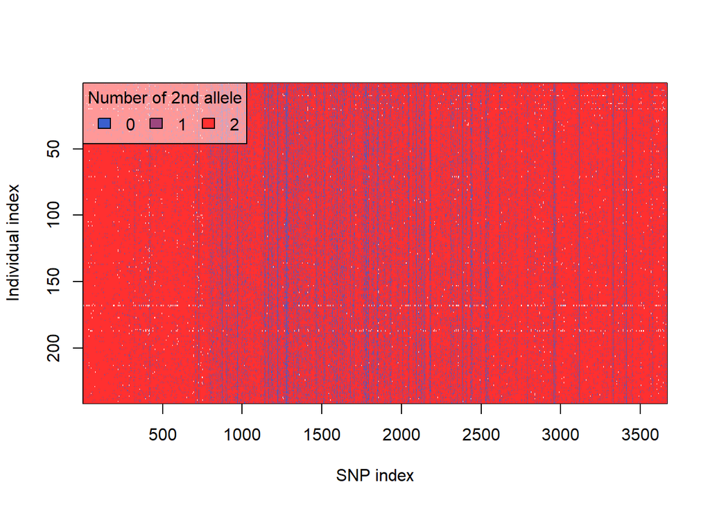

```r
# visualize the data
ogplot = adegenet::glPlot(orig_gl, posi="topleft")
```

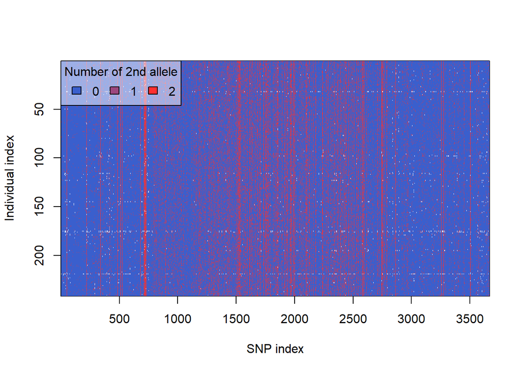

```r
newplot = adegenet::glPlot(new_gl, posi="topleft")
```

```r
#print(
#  gridExtra::grid.arrange(ogplot, newplot, nrow = 1, ncol = 2)
#)
```

### STATS

Below I calculate some basic stats for each dataset

```r
#Note: Importantly, this function in dartR implements basic.stats from Heiferstat (I assume, it doesn't specify the package on which this function is dependent in the dartR documentation, only the function "basic.stats"), which accounts for population information in some calculations and that is accounted for below account for that.

orig_gl.nopop <- orig_gl
orig_gl.nopop@pop <- factor(rep("A", length(new_gl@pop)), levels = "A")
stats_og <- dartR::gl.basic.stats(orig_gl.nopop)
```

```
## Starting ::
##  Starting dartR
##  Starting gl.basic.stats
##   Processing genlight object with SNP data
## Completed: ::
##  Completed: dartR
##  Completed: gl.basic.stats
```

```r
new_gl.nopop<-  new_gl
new_gl.nopop@pop <- factor(rep("A", length(new_gl@pop)), levels = "A")
stats_new <- dartR::gl.basic.stats(new_gl)
```

```
## Starting ::
##  Starting dartR
##  Starting gl.basic.stats
##   Processing genlight object with SNP data
## Completed: ::
##  Completed: dartR
##  Completed: gl.basic.stats
```

```r
# og
print(stats_og$overall)
```

```
##     Ho     Hs     Ht    Dst    Htp   Dstp    Fst   Fstp    Fis   Dest
## 0.1527 0.1542 0.1542 0.0000    NaN    NaN 0.0000    NaN 0.0102    NaN
```

```r
#re
print(stats_new$overall)
```

```
##     Ho     Hs     Ht    Dst    Htp   Dstp    Fst   Fstp    Fis   Dest
## 0.1749 0.1766 0.1768 0.0002 0.1768 0.0002 0.0012 0.0013 0.0095 0.0003
```

Because these calculations are averaged over loci, we would expect the results to be the same if that data were in either the same order (samples, loci) or even in a mixed order. The differences in Ho, He (overall) indicate that while overall the number of loci, individuals and missingness doesn’t change, the data is indeed different, again confirming numerically that the published dataused was indeed courrupted.

#### Missingness per indivudal

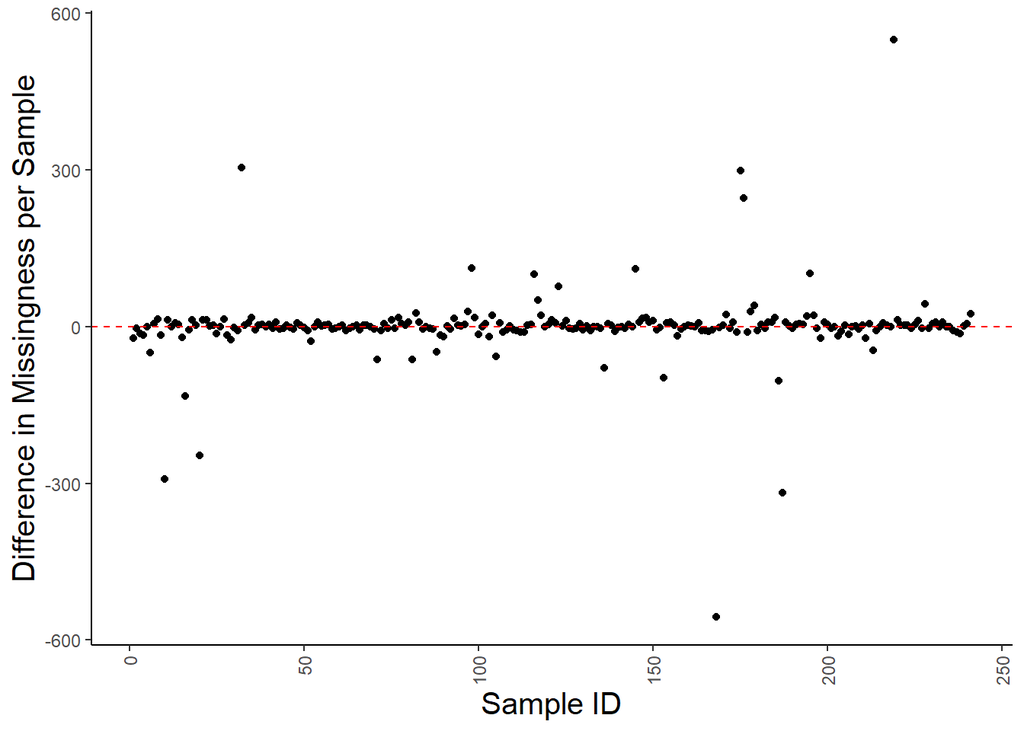

```r
missingness_new <- rowSums(is.na(as.matrix(new_gl)))
missingness_old <- rowSums(is.na(as.matrix(orig_gl)))

print(
data.frame(MISS_OG = missingness_new, MISS_NEW = missingness_old) %>%
  dplyr::mutate(DIFF = MISS_OG - MISS_NEW)  %>%
  tibble::rowid_to_column() %>%
  ggplot2::ggplot(., aes(x = rowid, y = DIFF)) +
  geom_point() +
  geom_hline(yintercept=0, linetype="dashed", color = "red") +
  labs(y = "Difference in Missingness per Sample", x = "Sample ID") +
  ggplot2::theme_classic() +
  theme(
      legend.position = "none",
      axis.title.x = ggplot2::element_text(size = 15),
      axis.title.y = ggplot2::element_text(size = 15),
      strip.text.x = ggplot2::element_blank(),
      axis.text.x = element_text(angle = 90, vjust = 0.5, hjust=1))
)
```

```r
# length(which(sort(missingness_new) == sort(missingness_old)))
```

```
## Starting ::
##  Starting dartR
##  Starting gl.report.heterozygosity
##   Processing genlight object with SNP data
##   Calculating observed heterozygosity for individuals
##   Note: No adjustment for invariant loci (n.invariant set to 0)
```

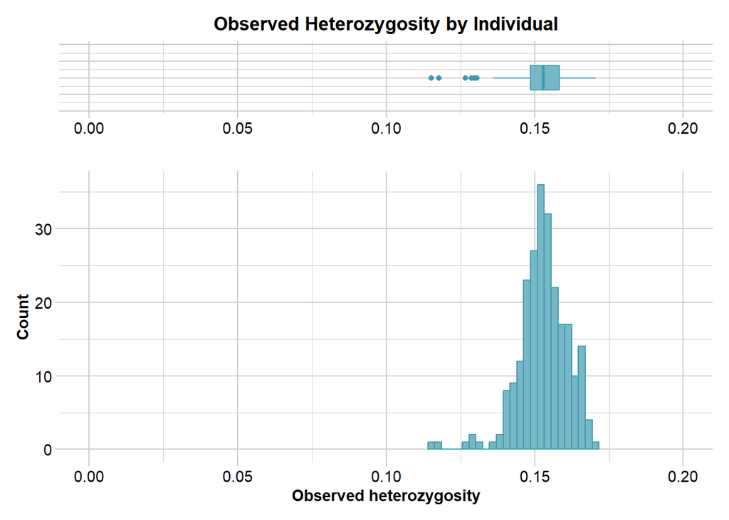

[output not shown]

[output cut: 190 more lines]

[output not shown]

```
## Starting ::
##  Starting dartR
##  Starting gl.report.heterozygosity
##   Processing genlight object with SNP data
##   Calculating observed heterozygosity for individuals
##   Note: No adjustment for invariant loci (n.invariant set to 0)
```

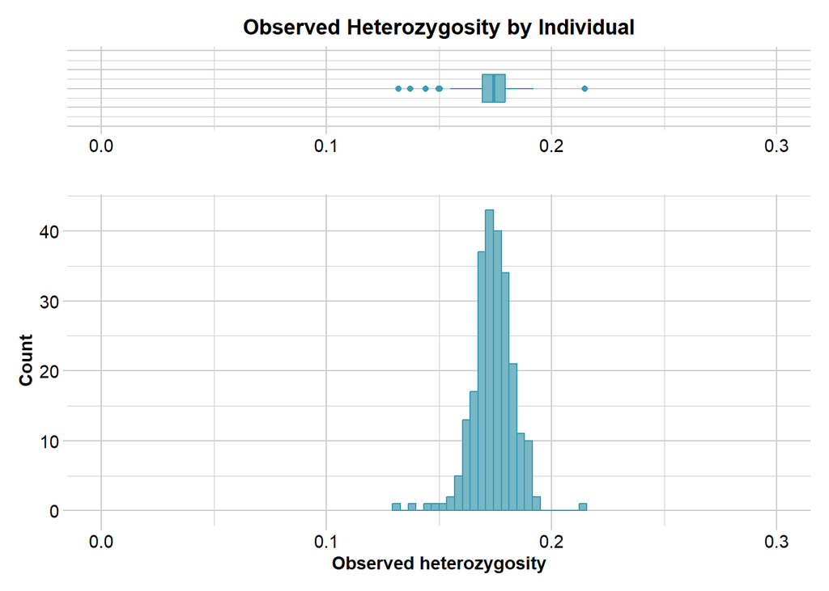

[output not shown]

[output cut: 190 more lines]

[output not shown]

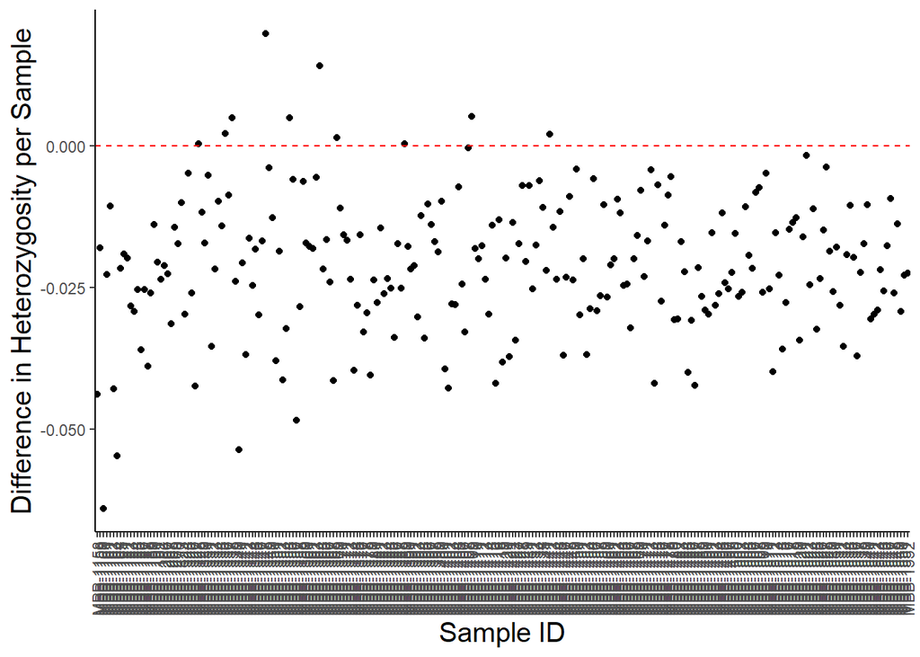

#### PCA

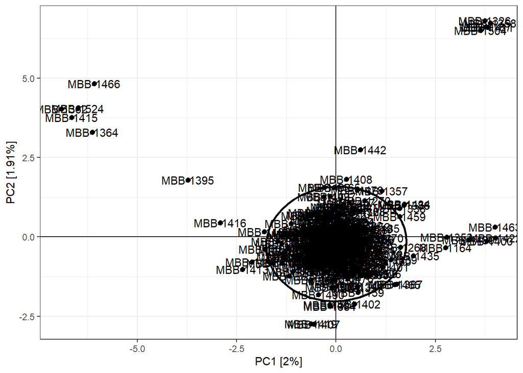

```r
# origional
pca_og <- glPca(orig_gl, nf = 20)
eig =pca_og$eig[!is.na(pca_og$eig)]
#barplot(100*eig/sum(eig), main="PCA Eigenvalues")
## plot basic pca - PC1 v PC2
print(
  as.data.frame(pca_og$scores) %>%
      tibble::rownames_to_column(., var ='ID') %>%
      ggplot(., aes(x=PC1, y=PC2, label = ID))  +
      geom_point(size=2) +
      geom_text() +
      stat_ellipse(level = 0.95, size = 1) +
      #scale_color_manual(values = cmilli_colors) +
      geom_hline(yintercept = 0) +
      geom_vline(xintercept = 0) +
      theme_bw() +
      xlab(paste0("PC1 [",paste0(round(eig[1], 2)), "%]")) +
      ylab(paste0("PC2 [",paste0(round(eig[2], 2)), "%]"))
)
```

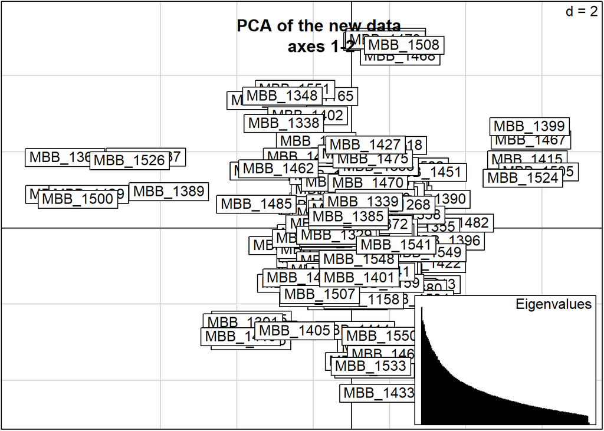

```r
#scatter(pca_og, posi="none")
#title("PCA of the original data\n axes 1-2")
# new
pca_new <- glPca(new_gl, nf = 20)
scatter(pca_new, posi="bottomright")
title("PCA of the new data\n axes 1-2")
```

The PCA indicates the error introduced into the published data changes the position of individuals in the pca.

## CORRECTING ESTIMATES

Below, I re-make input files for NeEstimator and COLONY so as to make new estimates of Nb using a new file made from the published list of loci (“new_gp”). I use dartR to write out a genepop file, and a custom script to write out a colony file. These files are manually scanned to ensure they have been written out correctly, and checked by plotting a pca of samples.

```r
current_path = getwd()

# 1. write out new_gp as a genepop , check that the file has been written out correctly
# 1a. run this file through NeEstimator

# first its important to make sure that the cohort are correctly assigned
cohort_assignment = readr::read_tsv("Report/Cohort_Assignment.tsv") %>%
  separate(MBB_CODE, into = c("string1", "string2"), sep = " ", remove = FALSE) %>%
  unite(MBB_CODE_JOIN, string1, string2, sep = "_")
ind_order = tibble::tibble(MBB_CODE_JOIN = new_gl$ind.names, OLD_STRATA = new_gl@pop) %>%
  left_join(., cohort_assignment, by = "MBB_CODE_JOIN")
new_gl@pop<- as.factor(ind_order$STRATA)

dartR::gl2genepop(new_gl, outfile = "new.gen", outpath = current_path)
```

Here i read in the data from the new genepop file for Ne estimator and run pca to make sure the data is written out correctly.

```r
#check
agenepop = adegenet::read.genepop("Report/new.gen", ncode = 2) # ncode, an integer indicating the number of characters used to code an allele
```

```
##
##  Converting data from a Genepop .gen file to a genind object...
##
##
## File description:  Genepop output. Loci: 3668 Populations: 11
##
## ...done.
```

```r
# # pca genepop
#  f1 <- function(vec) {
#         m <- mean(vec, na.rm = TRUE)
#         vec[is.na(vec)] <- m
#         return(vec)
#     }
#
# Y = apply(agenepop@tab,2,f1)
# dudi = dudi.pca(Y, nf = 20, scannf = FALSE)
# ind_coords = as.data.frame(dudi$li)
# ind_coords$Ind = indNames(agenepop)
# ggplot(data = ind_coords, aes(x = Axis1, y = Axis2, label = Ind))+
# geom_hline(yintercept = 0)+
# geom_vline(xintercept = 0)+
# #geom_point(shape = 21, size = 3, show.legend = FALSE)+
# geom_text(size = 5) +
# theme_bw()

# og pca
pca_new <- glPca(dartR::gi2gl(agenepop), nf = 20)
```

[output not shown]

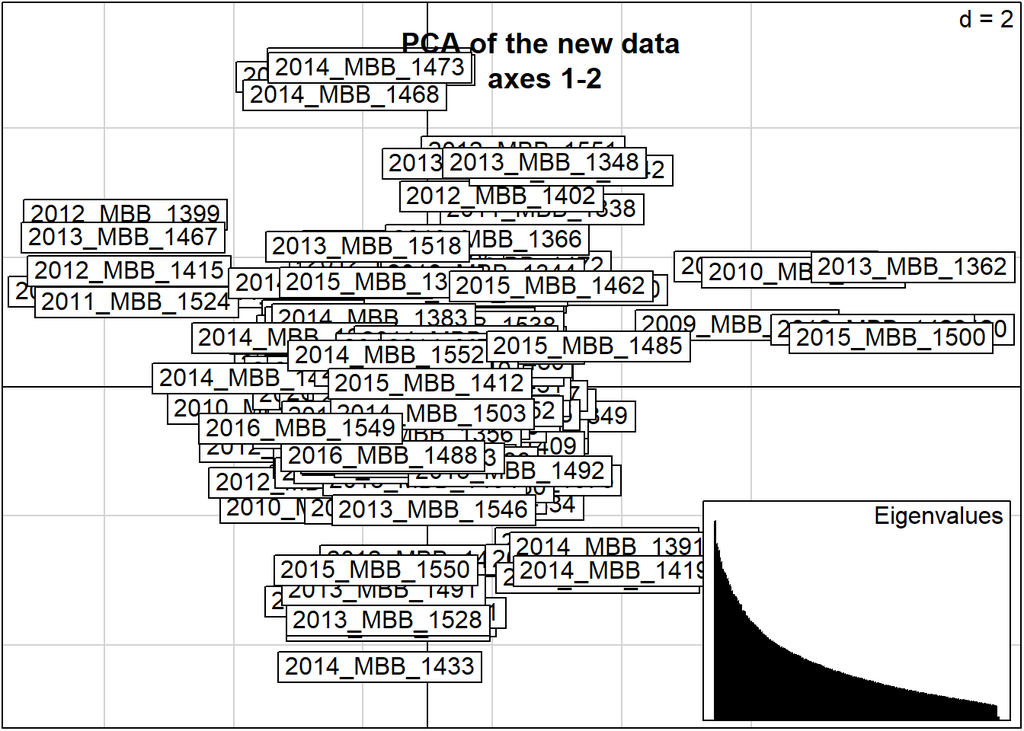

```r
scatter(pca_new, posi="bottomright")
title("PCA of the new data\n axes 1-2")
```

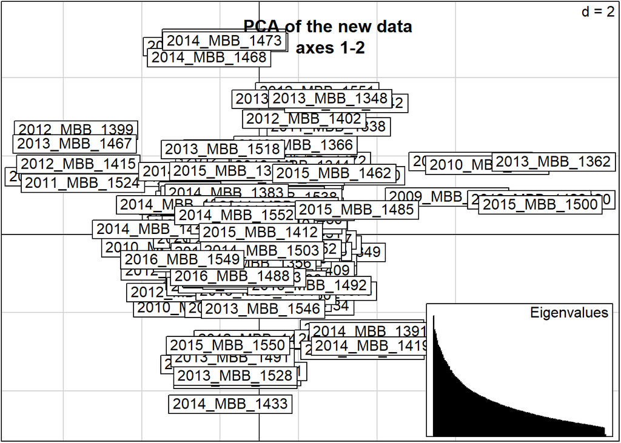

```r
# pca, in this pca, missing data are automatically replaced by the mean which is not that great tbh
pca_og <- glPca(new_gl, nf = 20)
scatter(pca_new, posi="bottomright")
title("PCA of the new data\n axes 1-2")
```

```r
# the orientation of the samples is slight, importantly the proximity of samples is maintained, basically the same
```

```r
# 2. write the same file to COLONY format , check that the file has been written out correctly
# 2b. run this file through COLONY

# write a colony file - (see website for specs) https://www.zsl.org/science/software/colony
for (obj in adegenet::seppop(agenepop)[2:length(levels(agenepop@pop))]){
data = obj
pop = levels(obj@pop)
marker.num = 3668
filename = paste(current_path, paste0(pop,"colony"), sep="/")
# line 1 - dataset name
line_1 = paste0(dQuote(paste0("Colony Input Pop: ", pop)),"                 ! Dataset name\n")
readr::write_file(line_1, filename, append = FALSE)
# line 2 - output file name
line_2 = paste0(dQuote(paste0("Output_", pop)),"                 ! Output file name\n")
readr::write_file(line_2, filename, append = T)
# line 3 - offspring number
line_3 <- paste(nrow(data), "                                  ! Number of offspring in the sample\n", sep = "")
readr::write_file(line_3, filename, append = T)
# line 4 - number of markers
line_4 <- paste(marker.num, "                                 ! Number of loci\n", sep = "")
readr::write_file(line_4, filename, append = T)
# line 5 - random seed
line_5 <- "1234                                 ! Seed for random number generator\n"
readr::write_file(line_5, filename, append = T)
# line 6 - allele frequency update?
line_6 <- "0                                    ! 0/1=Not updating/updating allele frequency\n"
readr::write_file(x = line_6, file = filename, append = TRUE)
# line 7 - dioecious/monecious
line_7 <- "2                                    ! 2/1=Dioecious/Monoecious species\n"
readr::write_file(x = line_7, file = filename, append = TRUE)
# line 8 - inbreeding
line_8 <- "0                                    ! 0/1=No inbreeding/inbreeding\n"
readr::write_file(x = line_8, file = filename, append = TRUE)
# line 9 - ploidy
line_9 <- "0                                    ! 0/1=Diploid species/HaploDiploid species\n"
readr::write_file(x = line_9, file = filename, append = TRUE)
# line 10 - mating system
line_10 <- paste("0","  ", "0", "                                 ! 0/1=Polygamy/Monogamy for males & females\n", sep = "")
readr::write_file(x = line_10, file = filename, append = TRUE)
# line 11 - clone inference
line_11 <- paste("0                                    ! 0/1=Clone inference =No/Yes\n", sep = "")
readr::write_file(x = line_11, file = filename, append = TRUE)
# line 12 - sibship size scaling
line_12 <- "1                                    ! 0/1=Full sibship size scaling =No/Yes\n"
readr::write_file(x = line_12, file = filename, append = TRUE)
# line 13 - sibship prior (0, 1, 2, 3 = No, weak, medium, strong sibship size prior; mean paternal & maternal sibship size)
line_13 <- "0 0 0                                ! 0, 1, 2, 3 = No, weak, medium, strong sibship size prior; mean paternal & maternal sibship size\n"
readr::write_file(x = line_13, file = filename, append = TRUE)
# line 14 - pop allele freq indiciator **note - if you set this to 1 you must add other lines inbetween line 14 and line 15
line_14 = "0                                    ! 0/1=Unknown/Known population allele frequency\n"
readr::write_file(x = line_14, file = filename, append = TRUE)
# line 15 - number of runs
line_15 <- "1                                    ! Number of runs\n"
readr::write_file(x = line_15, file = filename, append = TRUE)
# line 16 - length of run
line_16 <- "2                                ! Length of run\n"
readr::write_file(x = line_16, file = filename, append = TRUE)
# line 17 - 0/1=Monitor method by Iterate
line_17 <- "0                                    ! 0/1=Monitor method by Iterate\n"
readr::write_file(x = line_17, file = filename, append = TRUE)
# line 18 - monitor interval in Iterate
line_18 <- "10000                                ! Monitor interval in Iterate\n"
readr::write_file(x = line_18, file = filename, append = TRUE)
# line 19 - non-Windows version
line_19 <- "0                                    ! non-Windows version\n"
readr::write_file(x = line_19, file = filename, append = TRUE)
# line 20 - analysis 0 (Pairwise-Likelihood Score), 1 (Full Likelihood), 2 (combined Pairwise-Likelihood Score and Full Likelihood)
line_20 <- "1                                    ! Analysis 0 (Pairwise-Likelihood Score), 1 (Full Likelihood), 2 (combined Pairwise-Likelihood Score and Full Likelihood)\n"
readr::write_file(x = line_20, file = filename, append = TRUE)
# line 21 - 1/2/3=low/medium/high Precision for Full likelihood
line_21 <- "3                                    ! 1/2/3=low/medium/high Precision for Full likelihood\n"
readr::write_file(x = line_21, file = filename, append = TRUE)
# line 22 - marker IDs/Names
#snp.id = stringi::stri_join(seq(from = 1, to = marker.num, by = 1), collapse = " ")
line_22 <- paste0("\nmk@","                                    ! Marker IDs\n")
readr::write_file(x = line_22, file = filename, append = TRUE)
# line 23 - marker type (codominant/dominant)
#line_23 = stringi::stri_join(rep(0, marker.num), collapse = " ")
line_23 = "0@                                    ! Marker Type\n"
readr::write_file(x = line_23, file = filename, append = TRUE)
# line 24 - alellelic dropout rate
#line_24 <- stringi::stri_join(rep(0, marker.num), collapse = " ")
line_24 = "0@                                    ! Dropout Rate\n"
readr::write_file(x = line_24, file = filename, append = TRUE)
# line 25 - error rate (two new lines)
#error <- stringi::stri_join(rep(0.2, marker.num), collapse = " ")
error = paste0("0.02@                                    ! False allele rate\n", "\n")
#error <- paste0(error, "     ! False allele rate\n\n")
readr::write_file(x = error, file = filename, append = TRUE)
# line 26 - offspring id and genotype (two new lines after last inds)
# change homozygotes (0) to 11
# change heterozygote (1) to 12
# change homozygote (2) to 22
# change NA to 00
data = as.matrix(obj)
data[data == 0] <- "1,1"
data[data == 1] <- "1,2"
data[data == 2] <- "2,2"
data[is.na(data)]<- "0,0"

df = data.frame(data)
df = purrr:::reduce(seq_along(df),
       .init = df,
       ~ .x %>% separate(names(df)[.y],
                         sep = ',',
                         into = paste0(names(df)[.y], '_col_' , seq(1 + max(str_count(df[[.y]], ',')))),
                         fill = 'right'
                         )
)

utils::write.table(x = df, file = filename, sep = "\t", append = TRUE, col.names = FALSE, row.names = TRUE, quote = FALSE)

# line 27 - Prob. of dad/mum included in the candidates
line_27 <- "\n\n0  0                                 ! Prob. of dad/mum included in the candidates\n"
readr::write_file(x = line_27, file = filename, append = TRUE)
# line 28 - Numbers of candidate males & females
line_28 <- "0  0                                ! Numbers of candidate males & females\n"
readr::write_file(x = line_28, file = filename, append = TRUE)
# line 29 - Number of offspring with known father
line_29 <- "0  0                                 ! Number of offspring with known father\n"
readr::write_file(x = line_29, file = filename, append = TRUE)
# line 30 - Number of offspring with known mother
line_30 <- "0  0                                 ! Number of offspring with known mother\n"
readr::write_file(x = line_30, file = filename, append = TRUE)
# line 31 - Number of known paternal sibships
line_31 <- "0                                    ! Number of known paternal sibships\n"
readr::write_file(x = line_31, file = filename, append = TRUE)
# line 32 - Number of known maternal sibships
line_32 <- "0                                    ! Number of known paternal sibships\n"
readr::write_file(x = line_32, file = filename, append = TRUE)
# line 33 - Number of offspring with known excluded fathers
line_33 <- "0                                    ! Number of offspring with known excluded fathers\n"
readr::write_file(x = line_33, file = filename, append = TRUE)
# line 34 - Number of offspring with known excluded mothers
line_34 <- "0                                    ! Number of offspring with known excluded fathers\n"
readr::write_file(x = line_34, file = filename, append = TRUE)
# line 35 - Number of offspring with known excluded paternal sibships
line_35 <- "0                                    ! Number of offspring with known excluded fathers\n"
readr::write_file(x = line_35, file = filename, append = TRUE)
# line 36 - Number of offspring with known excluded maternal sibships
line_36 <- "0                                    ! Number of offspring with known excluded fathers\n"
readr::write_file(x = line_36, file = filename, append = TRUE)
}
# to run colony on command line, just make sure colony is installed in the same directory as the f
ls *colony > colonyinputfiles.txt
parallel -j15 ./Colony/colony2s.ifort.out IFN:{} :::: colonyinputfiles.txt
```

## Results

Outputs of NeEstimator and of Colony are saved in Report/NbResults.xlsx , where jacknife CIs are reported for pcrit = 0.05. The abbreviations “og” refers to published estimates, “re” refers to the new estimates using corrected file.

```r
knitr::kable(
  tibble::tibble(
  Measurement = c(2010, 2011, 2012, 2013),
  n = c(29,42,52,63),
  og_mono = c("705", "555", "468", "411"),
  og_nbld = c("193 (91-INF)", "195 (104-953)", "166 (104, 360)", "209 (116, 713)"),
  og_nbsa = c("271(136–1430)[2,2]", "344(204–923)[4,4]", "241(157–399)[8,6]", "289(200–461)[8,10]"),
  re_monomorphic =c("620", "379", "300", "191"),
  re_NbLD = c("62.7 (35.8-679.5)", "214.6 (104.8-551.1)", "215.5 (112.7-290.2)", "171.9 (117.3, 301.7)"),
  re_NbSA = c("96  (59,181)", "344  (211,872)", "285 (194,567)", "200 (147,297)"),
  og_combined = c("-", "233.2(±69.5)", "206.1(±45.9)", "252.0(±46.7)"),
  re_Combined = c("")
  )
)
```

| Measurement | n | og_mono | og_nbld | og_nbsa | re_monomorphic | re_NbLD | re_NbSA | og_combined | re_Combined |
| --- | --- | --- | --- | --- | --- | --- | --- | --- | --- |
| 2010 | 29 | 705 | 193 (91-INF) | 271(136–1430)[2,2] | 620 | 62.7 (35.8-679.5) | 96 (59,181) | - |  |
| 2011 | 42 | 555 | 195 (104-953) | 344(204–923)[4,4] | 379 | 214.6 (104.8-551.1) | 344 (211,872) | 233.2(±69.5) |  |
| 2012 | 52 | 468 | 166 (104, 360) | 241(157–399)[8,6] | 300 | 215.5 (112.7-290.2) | 285 (194,567) | 206.1(±45.9) |  |
| 2013 | 63 | 411 | 209 (116, 713) | 289(200–461)[8,10] | 191 | 171.9 (117.3, 301.7) | 200 (147,297) | 252.0(±46.7) |  |

## SENSITIVITY ANALYSIS

Below I perform a sensitivity/bootstrap analysis whereby 3000 loci from the raw (unfiltered) data are randomly sampled from 30 samples assigned to the 2013 cohort 10 times. The resulting files are used in NeEstimator only, to estimate the effective number of breeders (LDNb), the results summarized in a table(Results/Sensitivity), and are plotted for visualisation (using pcrit = 0.05).

### Make Sensitivity Analysis Files

Here, I run a sensitivity analysis using the 2013-cohort to provide an example. Here I use the raw data for the 2013-cohort (Loci = 9841 loci, N samples = 63) and I randomly sample without replacement 3000 loci and 30 samples 10 times.

```r
## following on from above
## make a matrix of 2013 samples and loci from the raw data (unfiltered)

input = dartR::gl.read.dart("Data/Raw/Report-DSha18-3402/Raw_Data_Original_DO_NOT_EDIT/Report_DSha18-3402_SNP_2_ReLabeled.csv")
# add strata info
pop = dplyr::left_join(tibble::tibble(TARGET_ID=str_replace_all(input@ind.names, "_", "-")), strata_info, by = "TARGET_ID")
input@pop<- factor(pop$STRATA)
# get only the 2013 samples
input2013 = adegenet::seppop(input, keepNA = TRUE)$"2013" #63 samples, 9841 loci
rand_gi_list<- list()
for(i in c(1:10)){
  rand_gi_list[[i]]<-  input2013[sample(c(1:63), size = 30, replace = F),sample(c(1:9841), size = 3000, replace = F)]
}

# write each one out into a genepop for neestimator
output_path = "Report/"
for (i in 1:10){
dartR::gl2genepop(rand_gi_list[[i]], outfile = paste0(i, ".gen"), outpath = output_path)
}
```

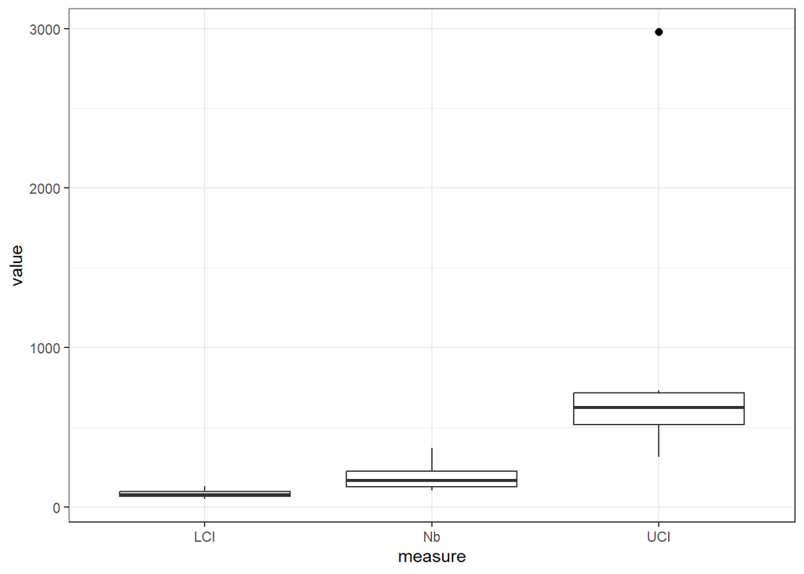

```r
#  plot results, summarised in sensitivity.csv -> bar chart of point estimates, LCI and UCI
sens = readxl::read_excel('Report/Sensitivity.xlsx', col_type = 'numeric')
sens %>%
    tidyr::pivot_longer(., everything(), names_to = "measure", values_to = "value") %>%
    ggplot(., aes(x = measure, y = value)) +
    geom_boxplot(outlier.colour="black", outlier.shape=16,
             outlier.size=2, notch=FALSE) +
    theme_bw()
```